# Risk Factor Analysis

## Outcome Variable

**Outcome Variable:** swasted

## Predictor Variables

**Intervention Variable:** sex

**Adjustment Set:**

unadjusted

## Stratifying Variables

The analysis was stratified on these variable(s):

- agecat
- studyid
- country

## Data Summary

| agecat | studyid | country | sex | swasted | n_cell | n |
| --- | --- | --- | --- | --- | --- | --- |
| Birth | ki0047075b-MAL-ED | BANGLADESH | Female | 0 | 116 | 241 |
| Birth | ki0047075b-MAL-ED | BANGLADESH | Female | 1 | 3 | 241 |
| Birth | ki0047075b-MAL-ED | BANGLADESH | Male | 0 | 117 | 241 |
| Birth | ki0047075b-MAL-ED | BANGLADESH | Male | 1 | 5 | 241 |
| Birth | ki0047075b-MAL-ED | BRAZIL | Female | 0 | 86 | 183 |
| Birth | ki0047075b-MAL-ED | BRAZIL | Female | 1 | 0 | 183 |
| Birth | ki0047075b-MAL-ED | BRAZIL | Male | 0 | 97 | 183 |
| Birth | ki0047075b-MAL-ED | BRAZIL | Male | 1 | 0 | 183 |
| Birth | ki0047075b-MAL-ED | INDIA | Female | 0 | 104 | 203 |
| Birth | ki0047075b-MAL-ED | INDIA | Female | 1 | 4 | 203 |
| Birth | ki0047075b-MAL-ED | INDIA | Male | 0 | 92 | 203 |
| Birth | ki0047075b-MAL-ED | INDIA | Male | 1 | 3 | 203 |
| Birth | ki0047075b-MAL-ED | NEPAL | Female | 0 | 79 | 168 |
| Birth | ki0047075b-MAL-ED | NEPAL | Female | 1 | 3 | 168 |
| Birth | ki0047075b-MAL-ED | NEPAL | Male | 0 | 85 | 168 |
| Birth | ki0047075b-MAL-ED | NEPAL | Male | 1 | 1 | 168 |
| Birth | ki0047075b-MAL-ED | PERU | Female | 0 | 127 | 279 |
| Birth | ki0047075b-MAL-ED | PERU | Female | 1 | 0 | 279 |
| Birth | ki0047075b-MAL-ED | PERU | Male | 0 | 152 | 279 |
| Birth | ki0047075b-MAL-ED | PERU | Male | 1 | 0 | 279 |
| Birth | ki0047075b-MAL-ED | SOUTH AFRICA | Female | 0 | 128 | 258 |
| Birth | ki0047075b-MAL-ED | SOUTH AFRICA | Female | 1 | 0 | 258 |
| Birth | ki0047075b-MAL-ED | SOUTH AFRICA | Male | 0 | 128 | 258 |
| Birth | ki0047075b-MAL-ED | SOUTH AFRICA | Male | 1 | 2 | 258 |
| Birth | ki0047075b-MAL-ED | TANZANIA, UNITED REPUBLIC OF | Female | 0 | 58 | 118 |
| Birth | ki0047075b-MAL-ED | TANZANIA, UNITED REPUBLIC OF | Female | 1 | 0 | 118 |
| Birth | ki0047075b-MAL-ED | TANZANIA, UNITED REPUBLIC OF | Male | 0 | 59 | 118 |
| Birth | ki0047075b-MAL-ED | TANZANIA, UNITED REPUBLIC OF | Male | 1 | 1 | 118 |
| Birth | ki1000108-CMC-V-BCS-2002 | INDIA | Female | 0 | 42 | 88 |
| Birth | ki1000108-CMC-V-BCS-2002 | INDIA | Female | 1 | 4 | 88 |

[output cut: 314 more lines]

The following strata were considered:

- agecat: 24 months, studyid: ki0047075b-MAL-ED, country: BANGLADESH
- agecat: 24 months, studyid: ki0047075b-MAL-ED, country: BRAZIL
- agecat: 24 months, studyid: ki0047075b-MAL-ED, country: INDIA
- agecat: 24 months, studyid: ki0047075b-MAL-ED, country: NEPAL
- agecat: 24 months, studyid: ki0047075b-MAL-ED, country: PERU
- agecat: 24 months, studyid: ki0047075b-MAL-ED, country: SOUTH AFRICA
- agecat: 24 months, studyid: ki0047075b-MAL-ED, country: TANZANIA, UNITED REPUBLIC OF
- agecat: 24 months, studyid: ki1000108-CMC-V-BCS-2002, country: INDIA
- agecat: 24 months, studyid: ki1000108-IRC, country: INDIA
- agecat: 24 months, studyid: ki1017093-NIH-Birth, country: BANGLADESH
- agecat: 24 months, studyid: ki1017093b-PROVIDE, country: BANGLADESH
- agecat: 24 months, studyid: ki1017093c-NIH-Crypto, country: BANGLADESH
- agecat: 24 months, studyid: ki1066203-TanzaniaChild2, country: TANZANIA, UNITED REPUBLIC OF
- agecat: 24 months, studyid: ki1101329-Keneba, country: GAMBIA
- agecat: 24 months, studyid: ki1113344-GMS-Nepal, country: NEPAL
- agecat: 24 months, studyid: ki1114097-CMIN, country: BANGLADESH
- agecat: 24 months, studyid: ki1114097-CMIN, country: GUINEA-BISSAU
- agecat: 24 months, studyid: ki1114097-CMIN, country: PERU
- agecat: 24 months, studyid: ki1114097-CONTENT, country: PERU
- agecat: 24 months, studyid: ki1119695-PROBIT, country: BELARUS
- agecat: 24 months, studyid: ki1126311-ZVITAMBO, country: ZIMBABWE
- agecat: 24 months, studyid: ki1135781-COHORTS, country: GUATEMALA
- agecat: 24 months, studyid: ki1135781-COHORTS, country: INDIA
- agecat: 24 months, studyid: ki1135781-COHORTS, country: PHILIPPINES
- agecat: 24 months, studyid: ki1148112-LCNI-5, country: MALAWI
- agecat: 24 months, studyid: kiGH5241-JiVitA-3, country: BANGLADESH
- agecat: 24 months, studyid: kiGH5241-JiVitA-4, country: BANGLADESH
- agecat: 6 months, studyid: ki0047075b-MAL-ED, country: BANGLADESH
- agecat: 6 months, studyid: ki0047075b-MAL-ED, country: BRAZIL
- agecat: 6 months, studyid: ki0047075b-MAL-ED, country: INDIA
- agecat: 6 months, studyid: ki0047075b-MAL-ED, country: NEPAL
- agecat: 6 months, studyid: ki0047075b-MAL-ED, country: PERU
- agecat: 6 months, studyid: ki0047075b-MAL-ED, country: SOUTH AFRICA
- agecat: 6 months, studyid: ki0047075b-MAL-ED, country: TANZANIA, UNITED REPUBLIC OF
- agecat: 6 months, studyid: ki1000108-CMC-V-BCS-2002, country: INDIA
- agecat: 6 months, studyid: ki1000108-IRC, country: INDIA
- agecat: 6 months, studyid: ki1000109-EE, country: PAKISTAN
- agecat: 6 months, studyid: ki1000109-ResPak, country: PAKISTAN
- agecat: 6 months, studyid: ki1000304b-SAS-CompFeed, country: INDIA
- agecat: 6 months, studyid: ki1000304b-SAS-FoodSuppl, country: INDIA
- agecat: 6 months, studyid: ki1017093-NIH-Birth, country: BANGLADESH
- agecat: 6 months, studyid: ki1017093b-PROVIDE, country: BANGLADESH
- agecat: 6 months, studyid: ki1017093c-NIH-Crypto, country: BANGLADESH
- agecat: 6 months, studyid: ki1066203-TanzaniaChild2, country: TANZANIA, UNITED REPUBLIC OF
- agecat: 6 months, studyid: ki1101329-Keneba, country: GAMBIA
- agecat: 6 months, studyid: ki1112895-Guatemala BSC, country: GUATEMALA
- agecat: 6 months, studyid: ki1113344-GMS-Nepal, country: NEPAL
- agecat: 6 months, studyid: ki1114097-CMIN, country: BANGLADESH
- agecat: 6 months, studyid: ki1114097-CMIN, country: BRAZIL
- agecat: 6 months, studyid: ki1114097-CMIN, country: GUINEA-BISSAU
- agecat: 6 months, studyid: ki1114097-CMIN, country: PERU
- agecat: 6 months, studyid: ki1114097-CONTENT, country: PERU
- agecat: 6 months, studyid: ki1119695-PROBIT, country: BELARUS
- agecat: 6 months, studyid: ki1126311-ZVITAMBO, country: ZIMBABWE
- agecat: 6 months, studyid: ki1135781-COHORTS, country: GUATEMALA
- agecat: 6 months, studyid: ki1135781-COHORTS, country: INDIA
- agecat: 6 months, studyid: ki1135781-COHORTS, country: PHILIPPINES
- agecat: 6 months, studyid: ki1148112-LCNI-5, country: MALAWI
- agecat: 6 months, studyid: kiGH5241-JiVitA-3, country: BANGLADESH
- agecat: 6 months, studyid: kiGH5241-JiVitA-4, country: BANGLADESH
- agecat: Birth, studyid: ki0047075b-MAL-ED, country: BANGLADESH
- agecat: Birth, studyid: ki0047075b-MAL-ED, country: BRAZIL
- agecat: Birth, studyid: ki0047075b-MAL-ED, country: INDIA
- agecat: Birth, studyid: ki0047075b-MAL-ED, country: NEPAL
- agecat: Birth, studyid: ki0047075b-MAL-ED, country: PERU
- agecat: Birth, studyid: ki0047075b-MAL-ED, country: SOUTH AFRICA
- agecat: Birth, studyid: ki0047075b-MAL-ED, country: TANZANIA, UNITED REPUBLIC OF
- agecat: Birth, studyid: ki1000108-CMC-V-BCS-2002, country: INDIA
- agecat: Birth, studyid: ki1000108-IRC, country: INDIA
- agecat: Birth, studyid: ki1000109-EE, country: PAKISTAN
- agecat: Birth, studyid: ki1000109-ResPak, country: PAKISTAN
- agecat: Birth, studyid: ki1000304b-SAS-CompFeed, country: INDIA
- agecat: Birth, studyid: ki1017093-NIH-Birth, country: BANGLADESH
- agecat: Birth, studyid: ki1017093c-NIH-Crypto, country: BANGLADESH
- agecat: Birth, studyid: ki1101329-Keneba, country: GAMBIA
- agecat: Birth, studyid: ki1114097-CMIN, country: BANGLADESH
- agecat: Birth, studyid: ki1114097-CMIN, country: BRAZIL
- agecat: Birth, studyid: ki1114097-CMIN, country: PERU
- agecat: Birth, studyid: ki1114097-CONTENT, country: PERU
- agecat: Birth, studyid: ki1119695-PROBIT, country: BELARUS
- agecat: Birth, studyid: ki1126311-ZVITAMBO, country: ZIMBABWE
- agecat: Birth, studyid: ki1135781-COHORTS, country: GUATEMALA
- agecat: Birth, studyid: ki1135781-COHORTS, country: INDIA
- agecat: Birth, studyid: ki1135781-COHORTS, country: PHILIPPINES
- agecat: Birth, studyid: kiGH5241-JiVitA-3, country: BANGLADESH
- agecat: Birth, studyid: kiGH5241-JiVitA-4, country: BANGLADESH

### Dropped Strata

Some strata were dropped due to rare outcomes:

- agecat: Birth, studyid: ki0047075b-MAL-ED, country: BANGLADESH
- agecat: Birth, studyid: ki0047075b-MAL-ED, country: BRAZIL
- agecat: Birth, studyid: ki0047075b-MAL-ED, country: INDIA
- agecat: Birth, studyid: ki0047075b-MAL-ED, country: NEPAL
- agecat: Birth, studyid: ki0047075b-MAL-ED, country: PERU
- agecat: Birth, studyid: ki0047075b-MAL-ED, country: SOUTH AFRICA
- agecat: Birth, studyid: ki0047075b-MAL-ED, country: TANZANIA, UNITED REPUBLIC OF
- agecat: Birth, studyid: ki1000108-CMC-V-BCS-2002, country: INDIA
- agecat: Birth, studyid: ki1000109-EE, country: PAKISTAN
- agecat: Birth, studyid: ki1000109-ResPak, country: PAKISTAN
- agecat: Birth, studyid: ki1000304b-SAS-CompFeed, country: INDIA
- agecat: Birth, studyid: ki1017093-NIH-Birth, country: BANGLADESH
- agecat: Birth, studyid: ki1017093c-NIH-Crypto, country: BANGLADESH
- agecat: Birth, studyid: ki1114097-CMIN, country: BANGLADESH
- agecat: Birth, studyid: ki1114097-CMIN, country: BRAZIL
- agecat: Birth, studyid: ki1114097-CMIN, country: PERU
- agecat: Birth, studyid: ki1114097-CONTENT, country: PERU
- agecat: Birth, studyid: kiGH5241-JiVitA-4, country: BANGLADESH
- agecat: 6 months, studyid: ki0047075b-MAL-ED, country: BANGLADESH
- agecat: 6 months, studyid: ki0047075b-MAL-ED, country: BRAZIL
- agecat: 6 months, studyid: ki0047075b-MAL-ED, country: INDIA
- agecat: 6 months, studyid: ki0047075b-MAL-ED, country: NEPAL
- agecat: 6 months, studyid: ki0047075b-MAL-ED, country: PERU
- agecat: 6 months, studyid: ki0047075b-MAL-ED, country: SOUTH AFRICA
- agecat: 6 months, studyid: ki0047075b-MAL-ED, country: TANZANIA, UNITED REPUBLIC OF
- agecat: 6 months, studyid: ki1000109-EE, country: PAKISTAN
- agecat: 6 months, studyid: ki1000109-ResPak, country: PAKISTAN
- agecat: 6 months, studyid: ki1017093-NIH-Birth, country: BANGLADESH
- agecat: 6 months, studyid: ki1017093b-PROVIDE, country: BANGLADESH
- agecat: 6 months, studyid: ki1017093c-NIH-Crypto, country: BANGLADESH
- agecat: 6 months, studyid: ki1066203-TanzaniaChild2, country: TANZANIA, UNITED REPUBLIC OF
- agecat: 6 months, studyid: ki1112895-Guatemala BSC, country: GUATEMALA
- agecat: 6 months, studyid: ki1113344-GMS-Nepal, country: NEPAL
- agecat: 6 months, studyid: ki1114097-CMIN, country: BANGLADESH
- agecat: 6 months, studyid: ki1114097-CMIN, country: BRAZIL
- agecat: 6 months, studyid: ki1114097-CMIN, country: GUINEA-BISSAU
- agecat: 6 months, studyid: ki1114097-CMIN, country: PERU
- agecat: 6 months, studyid: ki1114097-CONTENT, country: PERU
- agecat: 6 months, studyid: ki1119695-PROBIT, country: BELARUS
- agecat: 6 months, studyid: ki1135781-COHORTS, country: GUATEMALA
- agecat: 6 months, studyid: ki1148112-LCNI-5, country: MALAWI
- agecat: 24 months, studyid: ki0047075b-MAL-ED, country: BANGLADESH
- agecat: 24 months, studyid: ki0047075b-MAL-ED, country: BRAZIL
- agecat: 24 months, studyid: ki0047075b-MAL-ED, country: INDIA
- agecat: 24 months, studyid: ki0047075b-MAL-ED, country: NEPAL
- agecat: 24 months, studyid: ki0047075b-MAL-ED, country: PERU
- agecat: 24 months, studyid: ki0047075b-MAL-ED, country: SOUTH AFRICA
- agecat: 24 months, studyid: ki0047075b-MAL-ED, country: TANZANIA, UNITED REPUBLIC OF
- agecat: 24 months, studyid: ki1000108-CMC-V-BCS-2002, country: INDIA
- agecat: 24 months, studyid: ki1000108-IRC, country: INDIA
- agecat: 24 months, studyid: ki1017093-NIH-Birth, country: BANGLADESH
- agecat: 24 months, studyid: ki1017093b-PROVIDE, country: BANGLADESH
- agecat: 24 months, studyid: ki1017093c-NIH-Crypto, country: BANGLADESH
- agecat: 24 months, studyid: ki1066203-TanzaniaChild2, country: TANZANIA, UNITED REPUBLIC OF
- agecat: 24 months, studyid: ki1113344-GMS-Nepal, country: NEPAL
- agecat: 24 months, studyid: ki1114097-CMIN, country: BANGLADESH
- agecat: 24 months, studyid: ki1114097-CMIN, country: GUINEA-BISSAU
- agecat: 24 months, studyid: ki1114097-CMIN, country: PERU
- agecat: 24 months, studyid: ki1114097-CONTENT, country: PERU
- agecat: 24 months, studyid: ki1119695-PROBIT, country: BELARUS
- agecat: 24 months, studyid: ki1135781-COHORTS, country: GUATEMALA
- agecat: 24 months, studyid: ki1148112-LCNI-5, country: MALAWI

## Methods Detail

We’re interested in the causal parameters $E[Y_a]$ for all values of $a \in \mathcal{A}$. These parameters represent the mean outcome if, possibly contrary to fact, we intervened to set all units to have $A=a$. Under the randomization and positivity assumptions, these are identified by the statistical parameters $\psi_a=E_W[E_{Y|A,W}(Y|A=a,W)]$. In addition, we’re interested in the mean of $Y$, $E[Y]$ under no intervention (the observed mean). We will estimate these parameters by using SuperLearner to fit the relevant likelihood factors – $E_{Y|A,W}(Y|A=a,W)$ and $p(A=a|W)$, and then updating our likelihood fit using a joint TMLE.

For unadjusted analyses ($W=\{\}$), initial likelihoods were estimated using Lrnr_glm to estimate the simple $E(Y|A)$ and Lrnr_mean to estimate $p(A)$. For adjusted analyses, a small library containing Lrnr_glmnet, Lrnr_xgboost, and Lrnr_mean was used.

Having estimated these parameters, we will then use the delta method to estimate relative risks and attributable risks relative to a prespecified baseline level of $A$.

# Results Detail

## Results Plots

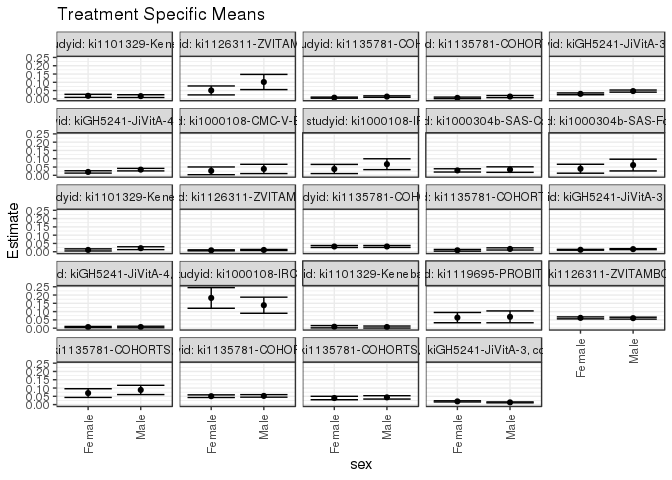

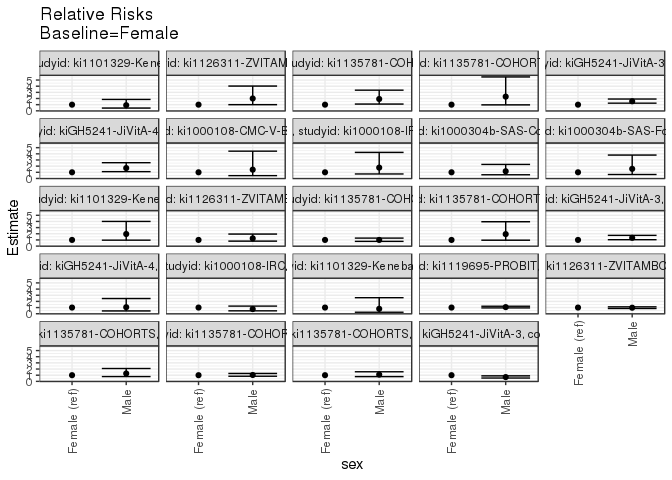

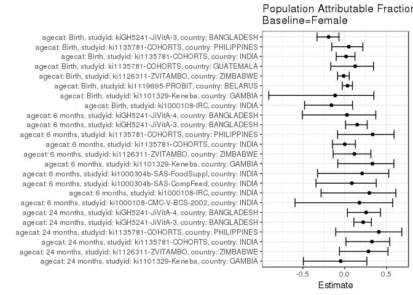

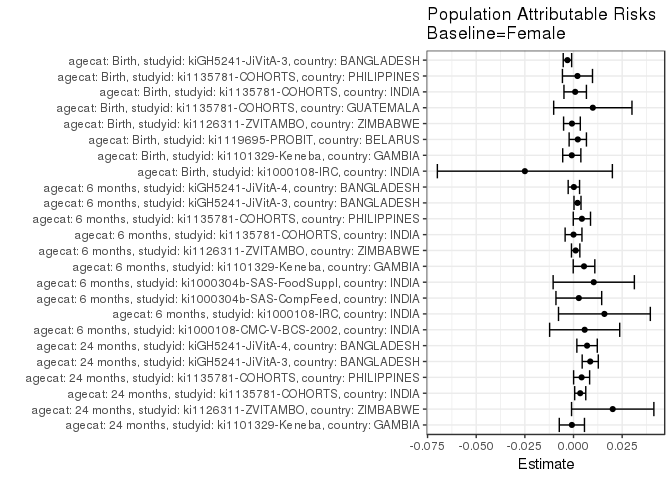

## Results Table

### Parameter: TSM

| agecat | studyid | country | intervention_level | baseline_level | estimate | ci_lower | ci_upper |
| --- | --- | --- | --- | --- | --- | --- | --- |
| Birth | ki1000108-IRC | INDIA | Female | NA | 0.1824324 | 0.1201215 | 0.2447433 |
| Birth | ki1000108-IRC | INDIA | Male | NA | 0.1384615 | 0.0899141 | 0.1870090 |
| Birth | ki1101329-Keneba | GAMBIA | Female | NA | 0.0086207 | 0.0017502 | 0.0154912 |
| Birth | ki1101329-Keneba | GAMBIA | Male | NA | 0.0068776 | 0.0008679 | 0.0128873 |
| Birth | ki1119695-PROBIT | BELARUS | Female | NA | 0.0637076 | 0.0327032 | 0.0947120 |
| Birth | ki1119695-PROBIT | BELARUS | Male | NA | 0.0682430 | 0.0325319 | 0.1039542 |
| Birth | ki1126311-ZVITAMBO | ZIMBABWE | Female | NA | 0.0620479 | 0.0560529 | 0.0680429 |
| Birth | ki1126311-ZVITAMBO | ZIMBABWE | Male | NA | 0.0604929 | 0.0547822 | 0.0662036 |
| Birth | ki1135781-COHORTS | GUATEMALA | Female | NA | 0.0694444 | 0.0431675 | 0.0957213 |
| Birth | ki1135781-COHORTS | GUATEMALA | Male | NA | 0.0883838 | 0.0604082 | 0.1163595 |
| Birth | ki1135781-COHORTS | INDIA | Female | NA | 0.0508130 | 0.0428900 | 0.0587360 |
| Birth | ki1135781-COHORTS | INDIA | Male | NA | 0.0524529 | 0.0447771 | 0.0601288 |
| Birth | ki1135781-COHORTS | PHILIPPINES | Female | NA | 0.0397059 | 0.0293262 | 0.0500855 |
| Birth | ki1135781-COHORTS | PHILIPPINES | Male | NA | 0.0435348 | 0.0333381 | 0.0537314 |
| Birth | kiGH5241-JiVitA-3 | BANGLADESH | Female | NA | 0.0192930 | 0.0157698 | 0.0228163 |
| Birth | kiGH5241-JiVitA-3 | BANGLADESH | Male | NA | 0.0133783 | 0.0106587 | 0.0160979 |
| 6 months | ki1000108-CMC-V-BCS-2002 | INDIA | Female | NA | 0.0268817 | 0.0036065 | 0.0501569 |
| 6 months | ki1000108-CMC-V-BCS-2002 | INDIA | Male | NA | 0.0384615 | 0.0104846 | 0.0664385 |
| 6 months | ki1000108-IRC | INDIA | Female | NA | 0.0380435 | 0.0103683 | 0.0657186 |
| 6 months | ki1000108-IRC | INDIA | Male | NA | 0.0669643 | 0.0341904 | 0.0997382 |
| 6 months | ki1000304b-SAS-CompFeed | INDIA | Female | NA | 0.0295082 | 0.0196810 | 0.0393354 |
| 6 months | ki1000304b-SAS-CompFeed | INDIA | Male | NA | 0.0345304 | 0.0178765 | 0.0511843 |
| 6 months | ki1000304b-SAS-FoodSuppl | INDIA | Female | NA | 0.0396040 | 0.0126738 | 0.0665341 |
| 6 months | ki1000304b-SAS-FoodSuppl | INDIA | Male | NA | 0.0617978 | 0.0263781 | 0.0972175 |
| 6 months | ki1101329-Keneba | GAMBIA | Female | NA | 0.0108803 | 0.0044841 | 0.0172765 |
| 6 months | ki1101329-Keneba | GAMBIA | Male | NA | 0.0213358 | 0.0127077 | 0.0299639 |
| 6 months | ki1126311-ZVITAMBO | ZIMBABWE | Female | NA | 0.0084577 | 0.0056267 | 0.0112887 |
| 6 months | ki1126311-ZVITAMBO | ZIMBABWE | Male | NA | 0.0106032 | 0.0075215 | 0.0136849 |
| 6 months | ki1135781-COHORTS | INDIA | Female | NA | 0.0316687 | 0.0256790 | 0.0376584 |
| 6 months | ki1135781-COHORTS | INDIA | Male | NA | 0.0316882 | 0.0259385 | 0.0374379 |
| 6 months | ki1135781-COHORTS | PHILIPPINES | Female | NA | 0.0086275 | 0.0035501 | 0.0137048 |
| 6 months | ki1135781-COHORTS | PHILIPPINES | Male | NA | 0.0167715 | 0.0101169 | 0.0234261 |
| 6 months | kiGH5241-JiVitA-3 | BANGLADESH | Female | NA | 0.0116590 | 0.0091799 | 0.0141381 |
| 6 months | kiGH5241-JiVitA-3 | BANGLADESH | Male | NA | 0.0156725 | 0.0127278 | 0.0186172 |
| 6 months | kiGH5241-JiVitA-4 | BANGLADESH | Female | NA | 0.0066445 | 0.0030623 | 0.0102267 |
| 6 months | kiGH5241-JiVitA-4 | BANGLADESH | Male | NA | 0.0070103 | 0.0023507 | 0.0116699 |
| 24 months | ki1101329-Keneba | GAMBIA | Female | NA | 0.0182260 | 0.0090843 | 0.0273677 |
| 24 months | ki1101329-Keneba | GAMBIA | Male | NA | 0.0166113 | 0.0082727 | 0.0249499 |
| 24 months | ki1126311-ZVITAMBO | ZIMBABWE | Female | NA | 0.0507813 | 0.0238549 | 0.0777076 |
| 24 months | ki1126311-ZVITAMBO | ZIMBABWE | Male | NA | 0.1017964 | 0.0558811 | 0.1477117 |
| 24 months | ki1135781-COHORTS | INDIA | Female | NA | 0.0071400 | 0.0038530 | 0.0104270 |
| 24 months | ki1135781-COHORTS | INDIA | Male | NA | 0.0137184 | 0.0093863 | 0.0180505 |
| 24 months | ki1135781-COHORTS | PHILIPPINES | Female | NA | 0.0060449 | 0.0015795 | 0.0105103 |
| 24 months | ki1135781-COHORTS | PHILIPPINES | Male | NA | 0.0139427 | 0.0075454 | 0.0203400 |
| 24 months | kiGH5241-JiVitA-3 | BANGLADESH | Female | NA | 0.0303468 | 0.0249460 | 0.0357477 |
| 24 months | kiGH5241-JiVitA-3 | BANGLADESH | Male | NA | 0.0469557 | 0.0406332 | 0.0532783 |
| 24 months | kiGH5241-JiVitA-4 | BANGLADESH | Female | NA | 0.0202788 | 0.0131621 | 0.0273956 |
| 24 months | kiGH5241-JiVitA-4 | BANGLADESH | Male | NA | 0.0342061 | 0.0265266 | 0.0418855 |

### Parameter: E(Y)

| agecat | studyid | country | intervention_level | baseline_level | estimate | ci_lower | ci_upper |
| --- | --- | --- | --- | --- | --- | --- | --- |
| Birth | ki1000108-IRC | INDIA | NA | NA | 0.1574344 | 0.1188345 | 0.1960344 |
| Birth | ki1101329-Keneba | GAMBIA | NA | NA | 0.0077301 | 0.0031781 | 0.0122822 |
| Birth | ki1119695-PROBIT | BELARUS | NA | NA | 0.0658999 | 0.0328405 | 0.0989593 |
| Birth | ki1126311-ZVITAMBO | ZIMBABWE | NA | NA | 0.0612419 | 0.0571066 | 0.0653771 |
| Birth | ki1135781-COHORTS | GUATEMALA | NA | NA | 0.0793651 | 0.0600839 | 0.0986462 |
| Birth | ki1135781-COHORTS | INDIA | NA | NA | 0.0516712 | 0.0461576 | 0.0571849 |
| Birth | ki1135781-COHORTS | PHILIPPINES | NA | NA | 0.0417385 | 0.0344572 | 0.0490198 |
| Birth | kiGH5241-JiVitA-3 | BANGLADESH | NA | NA | 0.0161691 | 0.0138058 | 0.0185324 |
| 6 months | ki1000108-CMC-V-BCS-2002 | INDIA | NA | NA | 0.0326087 | 0.0144375 | 0.0507799 |
| 6 months | ki1000108-IRC | INDIA | NA | NA | 0.0539216 | 0.0319786 | 0.0758646 |
| 6 months | ki1000304b-SAS-CompFeed | INDIA | NA | NA | 0.0322339 | 0.0235219 | 0.0409459 |
| 6 months | ki1000304b-SAS-FoodSuppl | INDIA | NA | NA | 0.0500000 | 0.0280580 | 0.0719420 |
| 6 months | ki1101329-Keneba | GAMBIA | NA | NA | 0.0162757 | 0.0108484 | 0.0217031 |
| 6 months | ki1126311-ZVITAMBO | ZIMBABWE | NA | NA | 0.0095595 | 0.0074615 | 0.0116576 |
| 6 months | ki1135781-COHORTS | INDIA | NA | NA | 0.0316788 | 0.0275309 | 0.0358267 |
| 6 months | ki1135781-COHORTS | PHILIPPINES | NA | NA | 0.0129342 | 0.0086762 | 0.0171922 |
| 6 months | kiGH5241-JiVitA-3 | BANGLADESH | NA | NA | 0.0137035 | 0.0116269 | 0.0157801 |
| 6 months | kiGH5241-JiVitA-4 | BANGLADESH | NA | NA | 0.0068281 | 0.0038634 | 0.0097927 |
| 24 months | ki1101329-Keneba | GAMBIA | NA | NA | 0.0173812 | 0.0112141 | 0.0235484 |
| 24 months | ki1126311-ZVITAMBO | ZIMBABWE | NA | NA | 0.0709220 | 0.0464309 | 0.0954131 |
| 24 months | ki1135781-COHORTS | INDIA | NA | NA | 0.0105840 | 0.0078264 | 0.0133416 |
| 24 months | ki1135781-COHORTS | PHILIPPINES | NA | NA | 0.0102082 | 0.0062264 | 0.0141901 |
| 24 months | kiGH5241-JiVitA-3 | BANGLADESH | NA | NA | 0.0389399 | 0.0346167 | 0.0432631 |
| 24 months | kiGH5241-JiVitA-4 | BANGLADESH | NA | NA | 0.0272439 | 0.0220352 | 0.0324527 |

### Parameter: RR

| agecat | studyid | country | intervention_level | baseline_level | estimate | ci_lower | ci_upper |
| --- | --- | --- | --- | --- | --- | --- | --- |
| Birth | ki1000108-IRC | INDIA | Female | Female | 1.0000000 | 1.0000000 | 1.000000 |
| Birth | ki1000108-IRC | INDIA | Male | Female | 0.7589744 | 0.4652073 | 1.238248 |
| Birth | ki1101329-Keneba | GAMBIA | Female | Female | 1.0000000 | 1.0000000 | 1.000000 |
| Birth | ki1101329-Keneba | GAMBIA | Male | Female | 0.7977992 | 0.2444924 | 2.603285 |
| Birth | ki1119695-PROBIT | BELARUS | Female | Female | 1.0000000 | 1.0000000 | 1.000000 |
| Birth | ki1119695-PROBIT | BELARUS | Male | Female | 1.0711908 | 0.9451627 | 1.214023 |
| Birth | ki1126311-ZVITAMBO | ZIMBABWE | Female | Female | 1.0000000 | 1.0000000 | 1.000000 |
| Birth | ki1126311-ZVITAMBO | ZIMBABWE | Male | Female | 0.9749388 | 0.8517495 | 1.115945 |
| Birth | ki1135781-COHORTS | GUATEMALA | Female | Female | 1.0000000 | 1.0000000 | 1.000000 |
| Birth | ki1135781-COHORTS | GUATEMALA | Male | Female | 1.2727273 | 0.7771218 | 2.084403 |
| Birth | ki1135781-COHORTS | INDIA | Female | Female | 1.0000000 | 1.0000000 | 1.000000 |
| Birth | ki1135781-COHORTS | INDIA | Male | Female | 1.0322740 | 0.8335385 | 1.278393 |
| Birth | ki1135781-COHORTS | PHILIPPINES | Female | Female | 1.0000000 | 1.0000000 | 1.000000 |
| Birth | ki1135781-COHORTS | PHILIPPINES | Male | Female | 1.0964311 | 0.7718761 | 1.557454 |
| Birth | kiGH5241-JiVitA-3 | BANGLADESH | Female | Female | 1.0000000 | 1.0000000 | 1.000000 |
| Birth | kiGH5241-JiVitA-3 | BANGLADESH | Male | Female | 0.6934278 | 0.5393618 | 0.891502 |
| 6 months | ki1000108-CMC-V-BCS-2002 | INDIA | Female | Female | 1.0000000 | 1.0000000 | 1.000000 |
| 6 months | ki1000108-CMC-V-BCS-2002 | INDIA | Male | Female | 1.4307692 | 0.4618005 | 4.432868 |
| 6 months | ki1000108-IRC | INDIA | Female | Female | 1.0000000 | 1.0000000 | 1.000000 |
| 6 months | ki1000108-IRC | INDIA | Male | Female | 1.7602041 | 0.7324610 | 4.230012 |
| 6 months | ki1000304b-SAS-CompFeed | INDIA | Female | Female | 1.0000000 | 1.0000000 | 1.000000 |
| 6 months | ki1000304b-SAS-CompFeed | INDIA | Male | Female | 1.1701964 | 0.6021138 | 2.274254 |
| 6 months | ki1000304b-SAS-FoodSuppl | INDIA | Female | Female | 1.0000000 | 1.0000000 | 1.000000 |
| 6 months | ki1000304b-SAS-FoodSuppl | INDIA | Male | Female | 1.5603933 | 0.6412208 | 3.797174 |
| 6 months | ki1101329-Keneba | GAMBIA | Female | Female | 1.0000000 | 1.0000000 | 1.000000 |
| 6 months | ki1101329-Keneba | GAMBIA | Male | Female | 1.9609546 | 0.9606954 | 4.002666 |
| 6 months | ki1126311-ZVITAMBO | ZIMBABWE | Female | Female | 1.0000000 | 1.0000000 | 1.000000 |
| 6 months | ki1126311-ZVITAMBO | ZIMBABWE | Male | Female | 1.2536730 | 0.8047528 | 1.953017 |
| 6 months | ki1135781-COHORTS | INDIA | Female | Female | 1.0000000 | 1.0000000 | 1.000000 |
| 6 months | ki1135781-COHORTS | INDIA | Male | Female | 1.0006148 | 0.7699087 | 1.300453 |
| 6 months | ki1135781-COHORTS | PHILIPPINES | Female | Female | 1.0000000 | 1.0000000 | 1.000000 |
| 6 months | ki1135781-COHORTS | PHILIPPINES | Male | Female | 1.9439680 | 0.9559607 | 3.953104 |
| 6 months | kiGH5241-JiVitA-3 | BANGLADESH | Female | Female | 1.0000000 | 1.0000000 | 1.000000 |
| 6 months | kiGH5241-JiVitA-3 | BANGLADESH | Male | Female | 1.3442446 | 1.0360230 | 1.744164 |
| 6 months | kiGH5241-JiVitA-4 | BANGLADESH | Female | Female | 1.0000000 | 1.0000000 | 1.000000 |
| 6 months | kiGH5241-JiVitA-4 | BANGLADESH | Male | Female | 1.0550515 | 0.4514153 | 2.465875 |
| 24 months | ki1101329-Keneba | GAMBIA | Female | Female | 1.0000000 | 1.0000000 | 1.000000 |
| 24 months | ki1101329-Keneba | GAMBIA | Male | Female | 0.9114064 | 0.4482567 | 1.853094 |
| 24 months | ki1126311-ZVITAMBO | ZIMBABWE | Female | Female | 1.0000000 | 1.0000000 | 1.000000 |
| 24 months | ki1126311-ZVITAMBO | ZIMBABWE | Male | Female | 2.0046062 | 0.9993141 | 4.021204 |
| 24 months | ki1135781-COHORTS | INDIA | Female | Female | 1.0000000 | 1.0000000 | 1.000000 |
| 24 months | ki1135781-COHORTS | INDIA | Male | Female | 1.9213397 | 1.0993985 | 3.357787 |
| 24 months | ki1135781-COHORTS | PHILIPPINES | Female | Female | 1.0000000 | 1.0000000 | 1.000000 |
| 24 months | ki1135781-COHORTS | PHILIPPINES | Male | Female | 2.3065173 | 0.9667024 | 5.503268 |
| 24 months | kiGH5241-JiVitA-3 | BANGLADESH | Female | Female | 1.0000000 | 1.0000000 | 1.000000 |
| 24 months | kiGH5241-JiVitA-3 | BANGLADESH | Male | Female | 1.5473034 | 1.2479214 | 1.918509 |
| 24 months | kiGH5241-JiVitA-4 | BANGLADESH | Female | Female | 1.0000000 | 1.0000000 | 1.000000 |
| 24 months | kiGH5241-JiVitA-4 | BANGLADESH | Male | Female | 1.6867874 | 1.1105597 | 2.561998 |

### Parameter: PAR

| agecat | studyid | country | intervention_level | baseline_level | estimate | ci_lower | ci_upper |
| --- | --- | --- | --- | --- | --- | --- | --- |
| Birth | ki1000108-IRC | INDIA | Female | NA | -0.0249980 | -0.0699645 | 0.0199684 |
| Birth | ki1101329-Keneba | GAMBIA | Female | NA | -0.0008905 | -0.0055542 | 0.0037731 |
| Birth | ki1119695-PROBIT | BELARUS | Female | NA | 0.0021922 | -0.0022554 | 0.0066398 |
| Birth | ki1126311-ZVITAMBO | ZIMBABWE | Female | NA | -0.0008060 | -0.0050978 | 0.0034857 |
| Birth | ki1135781-COHORTS | GUATEMALA | Female | NA | 0.0099206 | -0.0101951 | 0.0300364 |
| Birth | ki1135781-COHORTS | INDIA | Female | NA | 0.0008582 | -0.0049149 | 0.0066314 |
| Birth | ki1135781-COHORTS | PHILIPPINES | Female | NA | 0.0020326 | -0.0056920 | 0.0097573 |
| Birth | kiGH5241-JiVitA-3 | BANGLADESH | Female | NA | -0.0031240 | -0.0052892 | -0.0009587 |
| 6 months | ki1000108-CMC-V-BCS-2002 | INDIA | Female | NA | 0.0057270 | -0.0122814 | 0.0237354 |
| 6 months | ki1000108-IRC | INDIA | Female | NA | 0.0158781 | -0.0077139 | 0.0394701 |
| 6 months | ki1000304b-SAS-CompFeed | INDIA | Female | NA | 0.0027257 | -0.0090250 | 0.0144763 |
| 6 months | ki1000304b-SAS-FoodSuppl | INDIA | Female | NA | 0.0103960 | -0.0104761 | 0.0312682 |
| 6 months | ki1101329-Keneba | GAMBIA | Female | NA | 0.0053954 | -0.0001515 | 0.0109424 |
| 6 months | ki1126311-ZVITAMBO | ZIMBABWE | Female | NA | 0.0011018 | -0.0010474 | 0.0032510 |
| 6 months | ki1135781-COHORTS | INDIA | Female | NA | 0.0000101 | -0.0043121 | 0.0043324 |
| 6 months | ki1135781-COHORTS | PHILIPPINES | Female | NA | 0.0043068 | -0.0001223 | 0.0087359 |
| 6 months | kiGH5241-JiVitA-3 | BANGLADESH | Female | NA | 0.0020446 | 0.0002440 | 0.0038451 |
| 6 months | kiGH5241-JiVitA-4 | BANGLADESH | Female | NA | 0.0001835 | -0.0027424 | 0.0031094 |
| 24 months | ki1101329-Keneba | GAMBIA | Female | NA | -0.0008448 | -0.0073184 | 0.0056288 |
| 24 months | ki1126311-ZVITAMBO | ZIMBABWE | Female | NA | 0.0201407 | -0.0010080 | 0.0412894 |
| 24 months | ki1135781-COHORTS | INDIA | Female | NA | 0.0034440 | 0.0005957 | 0.0062923 |
| 24 months | ki1135781-COHORTS | PHILIPPINES | Female | NA | 0.0041633 | 0.0000477 | 0.0082790 |
| 24 months | kiGH5241-JiVitA-3 | BANGLADESH | Female | NA | 0.0085931 | 0.0044526 | 0.0127336 |
| 24 months | kiGH5241-JiVitA-4 | BANGLADESH | Female | NA | 0.0069651 | 0.0017170 | 0.0122132 |

### Parameter: PAF

| agecat | studyid | country | intervention_level | baseline_level | estimate | ci_lower | ci_upper |
| --- | --- | --- | --- | --- | --- | --- | --- |
| Birth | ki1000108-IRC | INDIA | Female | NA | -0.1587838 | -0.4807551 | 0.0931790 |
| Birth | ki1101329-Keneba | GAMBIA | Female | NA | -0.1152037 | -0.9091297 | 0.3485621 |
| Birth | ki1119695-PROBIT | BELARUS | Female | NA | 0.0332662 | -0.0292830 | 0.0920143 |
| Birth | ki1126311-ZVITAMBO | ZIMBABWE | Female | NA | -0.0131614 | -0.0857156 | 0.0545442 |
| Birth | ki1135781-COHORTS | GUATEMALA | Female | NA | 0.1250000 | -0.1669159 | 0.3438902 |
| Birth | ki1135781-COHORTS | INDIA | Female | NA | 0.0166095 | -0.1016995 | 0.1222135 |
| Birth | ki1135781-COHORTS | PHILIPPINES | Female | NA | 0.0486996 | -0.1553838 | 0.2167343 |
| Birth | kiGH5241-JiVitA-3 | BANGLADESH | Female | NA | -0.1932061 | -0.3316185 | -0.0691807 |
| 6 months | ki1000108-CMC-V-BCS-2002 | INDIA | Female | NA | 0.1756272 | -0.5948362 | 0.5738807 |
| 6 months | ki1000108-IRC | INDIA | Female | NA | 0.2944664 | -0.2834635 | 0.6121606 |
| 6 months | ki1000304b-SAS-CompFeed | INDIA | Female | NA | 0.0845597 | -0.3445988 | 0.3767427 |
| 6 months | ki1000304b-SAS-FoodSuppl | INDIA | Female | NA | 0.2079208 | -0.3261206 | 0.5268986 |
| 6 months | ki1101329-Keneba | GAMBIA | Female | NA | 0.3315006 | -0.0834585 | 0.5875324 |
| 6 months | ki1126311-ZVITAMBO | ZIMBABWE | Female | NA | 0.1152591 | -0.1388995 | 0.3126993 |
| 6 months | ki1135781-COHORTS | INDIA | Female | NA | 0.0003199 | -0.1458700 | 0.1278590 |
| 6 months | ki1135781-COHORTS | PHILIPPINES | Female | NA | 0.3329748 | -0.0853646 | 0.5900708 |
| 6 months | kiGH5241-JiVitA-3 | BANGLADESH | Female | NA | 0.1491990 | 0.0098353 | 0.2689475 |
| 6 months | kiGH5241-JiVitA-4 | BANGLADESH | Female | NA | 0.0268801 | -0.5070136 | 0.3716299 |
| 24 months | ki1101329-Keneba | GAMBIA | Female | NA | -0.0486027 | -0.4952249 | 0.2646139 |
| 24 months | ki1126311-ZVITAMBO | ZIMBABWE | Female | NA | 0.2839844 | -0.0637989 | 0.5180683 |
| 24 months | ki1135781-COHORTS | INDIA | Female | NA | 0.3253952 | 0.0146092 | 0.5381613 |
| 24 months | ki1135781-COHORTS | PHILIPPINES | Female | NA | 0.4078410 | -0.1077392 | 0.6834523 |
| 24 months | kiGH5241-JiVitA-3 | BANGLADESH | Female | NA | 0.2206755 | 0.1087567 | 0.3185400 |
| 24 months | kiGH5241-JiVitA-4 | BANGLADESH | Female | NA | 0.2556568 | 0.0324446 | 0.4273745 |